# Dataset is taken from Kaggle and the link to dataset is https://www.kaggle.com/trolukovich/food5k-image-dataset. This dataset has 3 folders training, validation and testing and images in each of them for train, validation and test purposes which are used as it is after unzipping the dataset.

# Importing Libraries

```python
import pandas as pd
import numpy as np
import matplotlib.pyplot as plt
import seaborn as sns
```

```python
# Setting the seed for the tensorflow

from tensorflow.python import set_random_seed
set_random_seed(2)
```

```python
from tensorflow.keras import datasets
from tensorflow.keras.preprocessing import image
from tensorflow.keras.optimizers import Adam
from tensorflow.keras.callbacks import EarlyStopping
from tensorflow.keras.preprocessing.image import ImageDataGenerator

from tensorflow.keras.layers import Activation, Conv2D, MaxPooling2D, Flatten, Dense, Dropout
from tensorflow.keras.models import Sequential
```

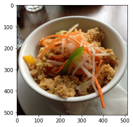

```python
# Displaying one food image

food = plt.imread('C:\\Users\\hites\\Downloads\\training\\food\\32.jpg')
plt.imshow(food)
```

```python
food.shape
```

```
(512, 512, 3)
```

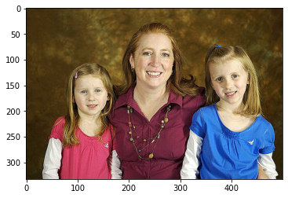

```python
# Displaying one non food image

non_food = plt.imread('C:\\Users\\hites\\Downloads\\training\\non_food\\32.jpg')
plt.imshow(non_food)
```

```python
non_food.shape
```

```
(333, 500, 3)
```

# Data Pre-processing

```python
# Define the Training Data directory

Train_dir = 'C:\\Users\\hites\\Downloads\\training'
```

```python
# Define the Validation Data directory

Test_dir = 'C:\\Users\\hites\\Downloads\\validation'
```

```python
# Define the Testing Data directory

Eval_dir = 'C:\\Users\\hites\\Downloads\\evaluation'
```

## ImageDataGenerator is an easy way to load and augment images in batches for image classification tasks. It ensures that the machine doesn't see the same image twice to avoid overfitting.

```python
# Data Augementation for training images and rescaling them between 0 to 1 for the models to process easily instead of RGB

train_datagen = ImageDataGenerator(rescale=1./255)
```

```python
# Data Augementation for validation images and rescaling them between 0 to 1 for the models to process easily instead of RGB

test_datagen = ImageDataGenerator(rescale=1./255)
```

```python
# Data Augementation for testing images and rescaling them between 0 to 1 for the models to process easily instead of RGB

eval_datagen = ImageDataGenerator(rescale=1./255)
```

## Using flow_from_directory() to generate batches of augmented image data (and their labels) directly from our jpgs in their respective folders.

```python
# Train Data Augmentation to generate images from the train directory with the set input size of 256*256

train_generator = train_datagen.flow_from_directory(
        Train_dir,  # this is the target directory
        target_size=(256, 256),  # all images will be resized to 256x256
        batch_size=16, # batch size of 16
        class_mode='binary', # since we use binary_crossentropy loss, we need binary labels
        classes=['food','non_food']) # Classes are defined as food and non_food
```

```
Found 3000 images belonging to 2 classes.
```

```python
# Train Data Augmentation to generate images from the train directory with the set input size changed to 128*128

train1_generator = train_datagen.flow_from_directory(
        Train_dir,  # this is the target directory
        target_size=(128, 128),  # all images will be resized to 128x128
        batch_size=16,
        class_mode='binary',
        classes=['food','non_food'])
```

```
Found 3000 images belonging to 2 classes.
```

```python
# Train Data Augmentation to generate images from the train directory with the set input size changed to 170*170

train2_generator = train_datagen.flow_from_directory(
        Train_dir,  # this is the target directory
        target_size=(170, 170),  # all images will be resized to 170x170
        batch_size=16,
        class_mode='binary',
        classes=['food','non_food'])
```

```
Found 3000 images belonging to 2 classes.
```

```python
# Validation Data Augmentation to generate images from the validation directory with the set input size of 256*256

validation_generator = test_datagen.flow_from_directory(
        Test_dir,
        target_size=(256, 256),
        batch_size=16,
        class_mode='binary',
        classes=['food','non_food'])
```

```
Found 1000 images belonging to 2 classes.
```

```python
# Validation Data Augmentation to generate images from the validation directory with the set input size changed to 128*128

validation1_generator = test_datagen.flow_from_directory(
        Test_dir,
        target_size=(128, 128),
        batch_size=16,
        class_mode='binary',
        classes=['food','non_food'])
```

```
Found 1000 images belonging to 2 classes.
```

```python
# Validation Data Augmentation to generate images from the validation directory with the set input size changed to 170*170

validation2_generator = test_datagen.flow_from_directory(
        Test_dir,
        target_size=(170, 170),
        batch_size=16,
        class_mode='binary',
        classes=['food','non_food'])
```

```
Found 1000 images belonging to 2 classes.
```

```python
# Test Data Augmentation to generate images from the test directory with the set input size of 256*256

eval_generator = eval_datagen.flow_from_directory(
        Eval_dir,  # this is the target directory
        target_size=(256, 256),  # all images will be resized to 256x256
        batch_size=16,
        class_mode='binary',
        classes=['food','non_food'])
```

```
Found 1000 images belonging to 2 classes.
```

```python
# Test Data Augmentation to generate images from the test directory with the set input size changed to 128*128

eval1_generator = eval_datagen.flow_from_directory(
        Eval_dir,  # this is the target directory
        target_size=(128, 128),  # all images will be resized to 150x150
        batch_size=16,
        class_mode='binary',
        classes=['food','non_food'])
```

```
Found 1000 images belonging to 2 classes.
```

```python
# Test Data Augmentation to generate images from the test directory with the set input size changed to 170*170

eval2_generator = eval_datagen.flow_from_directory(
        Eval_dir,  # this is the target directory
        target_size=(170, 170),  # all images will be resized to 150x150
        batch_size=16,
        class_mode='binary',
        classes=['food','non_food'])
```

```
Found 1000 images belonging to 2 classes.
```

# Convolutional Neural Networks Model Building for Image Classification into Food and Non-Food

### Model 1

### 3 Convolutional Layers with 16,32 and 64 number of filters, kernel/window size of 3*3, relu activation function, Maxpooling layer of 2*2 and dropout of 0.5

### 3 Maxpooling layers to reduce the size of the image after convolution

### Flatten to make the 2D output to feature vector to be used by Fuly Connected NN layer with 256 neurons and 1 output

```python
model = Sequential()
model.add(Conv2D(16, (3, 3), input_shape=(256, 256,3)))
model.add(Activation('relu'))
model.add(MaxPooling2D(pool_size=(2, 2)))
model.add(Dropout(0.5))

model.add(Conv2D(32, (3, 3)))
model.add(Activation('relu'))
model.add(MaxPooling2D(pool_size=(2, 2)))
model.add(Dropout(0.5))

model.add(Conv2D(64, (3, 3)))
model.add(Activation('relu'))
model.add(MaxPooling2D(pool_size=(2, 2)))
model.add(Dropout(0.5))

model.add(Flatten())
model.add(Dense(256))
model.add(Activation('relu'))
model.add(Dense(1))
model.add(Activation('sigmoid'))
```

```python
model.summary()
```

```
Model: "sequential"
_________________________________________________________________
Layer (type)                 Output Shape              Param #
=================================================================
conv2d (Conv2D)              (None, 254, 254, 16)      448
_________________________________________________________________
activation (Activation)      (None, 254, 254, 16)      0
_________________________________________________________________
max_pooling2d (MaxPooling2D) (None, 127, 127, 16)      0
_________________________________________________________________
dropout (Dropout)            (None, 127, 127, 16)      0
_________________________________________________________________
conv2d_1 (Conv2D)            (None, 125, 125, 32)      4640
_________________________________________________________________
activation_1 (Activation)    (None, 125, 125, 32)      0
_________________________________________________________________
max_pooling2d_1 (MaxPooling2 (None, 62, 62, 32)        0
_________________________________________________________________
dropout_1 (Dropout)          (None, 62, 62, 32)        0
_________________________________________________________________
conv2d_2 (Conv2D)            (None, 60, 60, 64)        18496
_________________________________________________________________
activation_2 (Activation)    (None, 60, 60, 64)        0
_________________________________________________________________
max_pooling2d_2 (MaxPooling2 (None, 30, 30, 64)        0
_________________________________________________________________
dropout_2 (Dropout)          (None, 30, 30, 64)        0
_________________________________________________________________
flatten (Flatten)            (None, 57600)             0
_________________________________________________________________
dense (Dense)                (None, 256)               14745856
_________________________________________________________________
activation_3 (Activation)    (None, 256)               0
_________________________________________________________________
dense_1 (Dense)              (None, 1)                 257
_________________________________________________________________
activation_4 (Activation)    (None, 1)                 0
=================================================================
Total params: 14,769,697
Trainable params: 14,769,697
Non-trainable params: 0
_________________________________________________________________
```

### 14.7 million weights for the network with 3 Convolutional Layers for the image classification

```python
# Defining the loss function for the image classification problem. As this is an binary image classification problem, using
# binary_crossentropy loss with Adam as the optimizer and metric as the accuracy.

model.compile(loss='binary_crossentropy',
              optimizer='adam',
              metrics=['accuracy'])
```

```python
# Fitting the model with input training images and validation images using images in the validation directory

history = model.fit_generator(
        train_generator,
        epochs=10,
        validation_data=validation_generator)
```

```
WARNING:tensorflow:From <ipython-input-25-b2b64d53260b>:1: Model.fit_generator (from tensorflow.python.keras.engine.training) is deprecated and will be removed in a future version.
Instructions for updating:
Please use Model.fit, which supports generators.
```

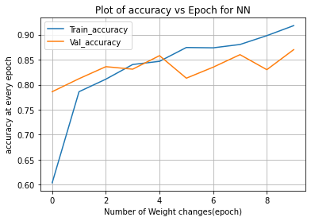

```python
# Training and Validation MSE plotted against the number of the epochs for the model

from matplotlib import pyplot as plt
plt.plot(history.epoch,history.history['accuracy'], label = 'Train_accuracy')
plt.plot(history.epoch,history.history['val_accuracy'], label = 'Val_accuracy')
plt.grid()
plt.ylabel('accuracy at every epoch')
plt.xlabel('Number of Weight changes(epoch)')
plt.title('Plot of accuracy vs Epoch for NN')
plt.legend()
```

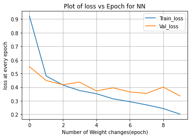

```python
# Training and Validation MSE plotted against the number of the epochs for the model

from matplotlib import pyplot as plt
plt.plot(history.epoch,history.history['loss'], label = 'Train_loss')
plt.plot(history.epoch,history.history['val_loss'], label = 'Val_loss')
plt.grid()
plt.ylabel('loss at every epoch')
plt.xlabel('Number of Weight changes(epoch)')
plt.title('Plot of loss vs Epoch for NN')
plt.legend()
```

### Prediction of Unknown Images from the Testing Directory to classify if the image is related to food or not

```python
# Reading a single test image of food

img_path = 'C:\\Users\\hites\\Downloads\\evaluation\\food\\234.jpg'
```

```python
# Reading a single test image of non food

img_path_non = 'C:\\Users\\hites\\Downloads\\evaluation\\non_food\\234.jpg'
```

```python
# Class labels to identify the images of the unseen images as food or non food

classes = train_generator.class_indices
```

```python
# Prediction of 0 means the image belongs to food item and prediction of 1 means the image belongs to non food image

print(classes)
```

```
{'food': 0, 'non_food': 1}
```

```python
# Predicting the unseen test image which is actually food

img = image.load_img(img_path, target_size=(256,256))
x = image.img_to_array(img)
x = np.expand_dims(x, axis=0)

images = np.vstack([x])
classes = model.predict_classes(images, batch_size=10)
print (classes)
```

[output not shown]

### We can see that the model is predicting correctly that the image is a food image with class label of 0 corresponding to food

```python
# Predicting the unseen test image which is actually non food

img_non = image.load_img(img_path_non, target_size=(256,256))
x_non = image.img_to_array(img_non)
x_non = np.expand_dims(x_non, axis=0)

images_non = np.vstack([x_non])
classes_non = model.predict_classes(images_non, batch_size=10)
print (classes_non)
```

[output not shown]

### We can see that the model is predicting correctly that the image is a non food image with class label of 1 corresponding to non food

```python
np.set_printoptions(suppress=True)
```

### Predicting the what each image in test data is using the predict_generator function close to 0 means food and close to 1 means non food for all the 1000 test images

```python
model.predict_generator(eval_generator)
```

```
WARNING:tensorflow:From <ipython-input-39-ea2af98fa01c>:1: Model.predict_generator (from tensorflow.python.keras.engine.training) is deprecated and will be removed in a future version.
Instructions for updating:
Please use Model.predict, which supports generators.
```

[output not shown]

[output cut: 945 more lines]

```
       [0.94582   ],
       [0.01686502],
       [0.14154941],
       [0.999931  ],
       [0.23367575],
       [0.99703014],
       [0.06995955],
       [0.0079467 ],
       [0.02510363],
       [0.2325105 ],
       [0.7183617 ],
       [0.22205764],
       [0.34247285],
       [0.13060534],
       [0.07851094]], dtype=float32)
```

### Model 2

### Dropout is changed from 0.5 in all the 3 Convolution layers to 0.3 in the 1st 2 Convolution layers and 0.5 in the last Convolution layer with all the other configurations being the same.

```python
model_1 = Sequential()
model_1.add(Conv2D(16, (3, 3), input_shape=(256, 256,3)))
model_1.add(Activation('relu'))
model_1.add(MaxPooling2D(pool_size=(2, 2)))
model_1.add(Dropout(0.3))

model_1.add(Conv2D(32, (3, 3)))
model_1.add(Activation('relu'))
model_1.add(MaxPooling2D(pool_size=(2, 2)))
model_1.add(Dropout(0.3))

model_1.add(Conv2D(64, (3, 3)))
model_1.add(Activation('relu'))
model_1.add(MaxPooling2D(pool_size=(2, 2)))
model_1.add(Dropout(0.5))

model_1.add(Flatten())
model_1.add(Dense(256))
model_1.add(Activation('relu'))
model_1.add(Dense(1))
model_1.add(Activation('sigmoid'))
```

```python
model_1.summary()
```

```
Model: "sequential_1"
_________________________________________________________________
Layer (type)                 Output Shape              Param #
=================================================================
conv2d_3 (Conv2D)            (None, 254, 254, 16)      448
_________________________________________________________________
activation_5 (Activation)    (None, 254, 254, 16)      0
_________________________________________________________________
max_pooling2d_3 (MaxPooling2 (None, 127, 127, 16)      0
_________________________________________________________________
dropout_3 (Dropout)          (None, 127, 127, 16)      0
_________________________________________________________________
conv2d_4 (Conv2D)            (None, 125, 125, 32)      4640
_________________________________________________________________
activation_6 (Activation)    (None, 125, 125, 32)      0
_________________________________________________________________
max_pooling2d_4 (MaxPooling2 (None, 62, 62, 32)        0
_________________________________________________________________
dropout_4 (Dropout)          (None, 62, 62, 32)        0
_________________________________________________________________
conv2d_5 (Conv2D)            (None, 60, 60, 64)        18496
_________________________________________________________________
activation_7 (Activation)    (None, 60, 60, 64)        0
_________________________________________________________________
max_pooling2d_5 (MaxPooling2 (None, 30, 30, 64)        0
_________________________________________________________________
dropout_5 (Dropout)          (None, 30, 30, 64)        0
_________________________________________________________________
flatten_1 (Flatten)          (None, 57600)             0
_________________________________________________________________
dense_2 (Dense)              (None, 256)               14745856
_________________________________________________________________
activation_8 (Activation)    (None, 256)               0
_________________________________________________________________
dense_3 (Dense)              (None, 1)                 257
_________________________________________________________________
activation_9 (Activation)    (None, 1)                 0
=================================================================
Total params: 14,769,697
Trainable params: 14,769,697
Non-trainable params: 0
_________________________________________________________________
```

### 14.7 million weights are updated for the Convolutional Neural Networks

```python
# Defining the loss function for the image classification problem. As this is an binary image classification problem, using
# binary_crossentropy loss with Adam as the optimizer and metric as the accuracy.

model_1.compile(loss='binary_crossentropy',
              optimizer='adam',
              metrics=['accuracy'])
```

```python
# Fitting the model with input training images and validation images using images in the validation directory

history_1 = model_1.fit_generator(
        train_generator,
        epochs=10,
        validation_data=validation_generator)
```

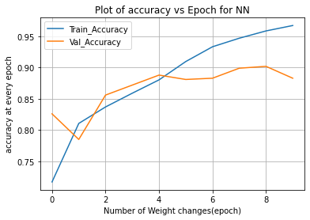

```python
# Training and Validation accuracy plotted against the number of the epochs for the model

from matplotlib import pyplot as plt
plt.plot(history_1.epoch,history_1.history['accuracy'], label = 'Train_Accuracy')
plt.plot(history_1.epoch,history_1.history['val_accuracy'], label = 'Val_Accuracy')
plt.grid()
plt.ylabel('accuracy at every epoch')
plt.xlabel('Number of Weight changes(epoch)')
plt.title('Plot of accuracy vs Epoch for NN')
plt.legend()
```

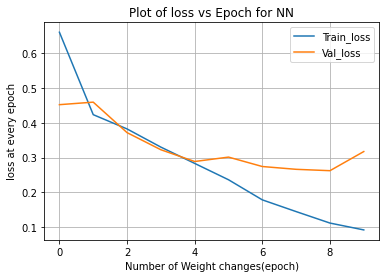

```python
# Training and Validation loss plotted against the number of the epochs for the model

from matplotlib import pyplot as plt
plt.plot(history_1.epoch,history_1.history['loss'], label = 'Train_loss')
plt.plot(history_1.epoch,history_1.history['val_loss'], label = 'Val_loss')
plt.grid()
plt.ylabel('loss at every epoch')
plt.xlabel('Number of Weight changes(epoch)')
plt.title('Plot of loss vs Epoch for NN')
plt.legend()
```

### EarlyStopping is used stop the model from training after certain iterations/epochs to prevent overfitting. There can be situations where after certain number of epochs the validation accuracy doesn't improve even though the training accuracy increases leading to overfitting. In such cases, we would to stop training the model at that instance which is where EarlyStopping is used.

### EarlyStopping to prevent the model from overfitting. Stops training the model if after 3 epochs the validation accuracy is not improving as we arre monitoring the validation accuracy which we want to be maximum

```python
es = EarlyStopping(monitor='val_accuracy', mode='max', verbose=1, patience=3)
```

### Model 3

### As in the case of model 2 which was overfitting I have tried to use EarlyStopping in order to see if we can prevent overfitting using this. Does the training stop if there is no improvement in the validation accuracy after 3 consecutive epochs.

### 3 convolutional layers with number of filters, kernel size, pooling size is all kept the same

```python
model_2 = Sequential()
model_2.add(Conv2D(16, (3, 3), input_shape=(256, 256,3)))
model_2.add(Activation('relu'))
model_2.add(MaxPooling2D(pool_size=(2, 2)))
model_2.add(Dropout(0.5))

model_2.add(Conv2D(32, (3, 3)))
model_2.add(Activation('relu'))
model_2.add(MaxPooling2D(pool_size=(2, 2)))
model_2.add(Dropout(0.3))

model_2.add(Conv2D(64, (3, 3)))
model_2.add(Activation('relu'))
model_2.add(MaxPooling2D(pool_size=(2, 2)))
model_2.add(Dropout(0.5))

model_2.add(Flatten())
model_2.add(Dense(256))
model_2.add(Activation('relu'))
model_2.add(Dense(1))
model_2.add(Activation('sigmoid'))
```

```python
model_2.summary()
```

```
Model: "sequential_8"
_________________________________________________________________
Layer (type)                 Output Shape              Param #
=================================================================
conv2d_45 (Conv2D)           (None, 254, 254, 16)      448
_________________________________________________________________
activation_67 (Activation)   (None, 254, 254, 16)      0
_________________________________________________________________
max_pooling2d_30 (MaxPooling (None, 127, 127, 16)      0
_________________________________________________________________
dropout_27 (Dropout)         (None, 127, 127, 16)      0
_________________________________________________________________
conv2d_46 (Conv2D)           (None, 125, 125, 32)      4640
_________________________________________________________________
activation_68 (Activation)   (None, 125, 125, 32)      0
_________________________________________________________________
max_pooling2d_31 (MaxPooling (None, 62, 62, 32)        0
_________________________________________________________________
dropout_28 (Dropout)         (None, 62, 62, 32)        0
_________________________________________________________________
conv2d_47 (Conv2D)           (None, 60, 60, 64)        18496
_________________________________________________________________
activation_69 (Activation)   (None, 60, 60, 64)        0
_________________________________________________________________
max_pooling2d_32 (MaxPooling (None, 30, 30, 64)        0
_________________________________________________________________
dropout_29 (Dropout)         (None, 30, 30, 64)        0
_________________________________________________________________
flatten_8 (Flatten)          (None, 57600)             0
_________________________________________________________________
dense_22 (Dense)             (None, 256)               14745856
_________________________________________________________________
activation_70 (Activation)   (None, 256)               0
_________________________________________________________________
dense_23 (Dense)             (None, 1)                 257
_________________________________________________________________
activation_71 (Activation)   (None, 1)                 0
=================================================================
Total params: 14,769,697
Trainable params: 14,769,697
Non-trainable params: 0
_________________________________________________________________
```

```python
# Defining the loss function for the image classification problem. As this is an binary image classification problem, using
# binary_crossentropy loss with Adam as the optimizer and metric as the accuracy.

model_2.compile(loss='binary_crossentropy',
              optimizer='adam',
              metrics=['accuracy'])
```

```python
# Fitting the model with input training images and validation images using images in the validation directory

history_2 = model_2.fit_generator(
        train_generator,
        epochs=10,
        validation_data=validation_generator,callbacks=[es])
```

```
Epoch 00009: early stopping
```

### As we can see that after the 8th Epoch the model training stops instead of continuing the training even though the validation accuracy is reducing for 3 consecutive epochs. We can avoid overfitting with this early stopping of training process.

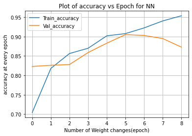

```python
# Training and Validation accuracy plotted against the number of the epochs for the model

from matplotlib import pyplot as plt
plt.plot(history_2.epoch,history_2.history['accuracy'], label = 'Train_accuracy')
plt.plot(history_2.epoch,history_2.history['val_accuracy'], label = 'Val_accuracy')
plt.grid()
plt.ylabel('accuracy at every epoch')
plt.xlabel('Number of Weight changes(epoch)')
plt.title('Plot of accuracy vs Epoch for NN')
plt.legend()
```

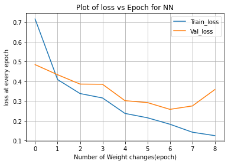

```python
# Training and Validation loss plotted against the number of the epochs for the model

from matplotlib import pyplot as plt
plt.plot(history_2.epoch,history_2.history['loss'], label = 'Train_loss')
plt.plot(history_2.epoch,history_2.history['val_loss'], label = 'Val_loss')
plt.grid()
plt.ylabel('loss at every epoch')
plt.xlabel('Number of Weight changes(epoch)')
plt.title('Plot of loss vs Epoch for NN')
plt.legend()
```

### From the graphs of Training vs Validation Accuracy and Training vs Validation loss, it can be seen that now even though the 2 curves tend to move in different directions they are not moving with the same difference as earlier. The gap is reduced between them. Also, we stopped at 8th epoch to avoid overfitting automatically. This saved us from time taken for training, computational cost in terms of weight updates and overfitting. EarlyStopping technique is very handy for the Deep Convolutional Networks

### Model 4

### Now, I increased the number of Convolutional Layers to 4 instead of 3. Also, for the 1st Convoltional Layer used 32 filters and not 16. The number of filters have increased for the convoltional layers.

### Also, in the final Dense layer the number of neurons have increased to 512 from 256.

### Convlotional Filters and Number of Layers are increased in this model to see if the depth of the CNN has any effect in the model building to predict accurately the food images.

```python
model_4 = Sequential()
model_4.add(Conv2D(32, (3, 3), input_shape=(256,256,3)))
model_4.add(Activation('relu'))
model_4.add(MaxPooling2D(pool_size=(2, 2)))
model_4.add(Dropout(0.3))

model_4.add(Conv2D(64, (3, 3)))
model_4.add(Activation('relu'))
model_4.add(MaxPooling2D(pool_size=(2, 2)))
model_4.add(Dropout(0.3))

model_4.add(Conv2D(128, (3, 3)))
model_4.add(Activation('relu'))
model_4.add(MaxPooling2D(pool_size=(2, 2)))
model_4.add(Dropout(0.3))

model_4.add(Conv2D(256, (3, 3)))
model_4.add(Activation('relu'))
model_4.add(MaxPooling2D(pool_size=(2, 2)))
model_4.add(Dropout(0.5))

model_4.add(Flatten())
model_4.add(Dense(512))
model_4.add(Activation('relu'))
model_4.add(Dense(1))
model_4.add(Activation('sigmoid'))
```

```python
# Defining the loss function for the image classification problem. As this is an binary image classification problem, using
# binary_crossentropy loss with Adam as the optimizer and metric as the accuracy.

model_4.compile(loss='binary_crossentropy',
              optimizer='adam',
              metrics=['accuracy'])
```

```python
model_4.summary()
```

```
Model: "sequential_9"
_________________________________________________________________
Layer (type)                 Output Shape              Param #
=================================================================
conv2d_48 (Conv2D)           (None, 254, 254, 32)      896
_________________________________________________________________
activation_72 (Activation)   (None, 254, 254, 32)      0
_________________________________________________________________
max_pooling2d_33 (MaxPooling (None, 127, 127, 32)      0
_________________________________________________________________
dropout_30 (Dropout)         (None, 127, 127, 32)      0
_________________________________________________________________
conv2d_49 (Conv2D)           (None, 125, 125, 64)      18496
_________________________________________________________________
activation_73 (Activation)   (None, 125, 125, 64)      0
_________________________________________________________________
max_pooling2d_34 (MaxPooling (None, 62, 62, 64)        0
_________________________________________________________________
dropout_31 (Dropout)         (None, 62, 62, 64)        0
_________________________________________________________________
conv2d_50 (Conv2D)           (None, 60, 60, 128)       73856
_________________________________________________________________
activation_74 (Activation)   (None, 60, 60, 128)       0
_________________________________________________________________
max_pooling2d_35 (MaxPooling (None, 30, 30, 128)       0
_________________________________________________________________
dropout_32 (Dropout)         (None, 30, 30, 128)       0
_________________________________________________________________
conv2d_51 (Conv2D)           (None, 28, 28, 256)       295168
_________________________________________________________________
activation_75 (Activation)   (None, 28, 28, 256)       0
_________________________________________________________________
max_pooling2d_36 (MaxPooling (None, 14, 14, 256)       0
_________________________________________________________________
dropout_33 (Dropout)         (None, 14, 14, 256)       0
_________________________________________________________________
flatten_9 (Flatten)          (None, 50176)             0
_________________________________________________________________
dense_24 (Dense)             (None, 512)               25690624
_________________________________________________________________
activation_76 (Activation)   (None, 512)               0
_________________________________________________________________
dense_25 (Dense)             (None, 1)                 513
_________________________________________________________________
activation_77 (Activation)   (None, 1)                 0
=================================================================
Total params: 26,079,553
Trainable params: 26,079,553
Non-trainable params: 0
_________________________________________________________________
```

### With 1 added extra convolutional layer of 256 filters along with more filters in the 1st conv. layer and last dense layer having 512 neurons instead of 256 has increased the number of weights to 26 million from 14.7 million making the network almost double the complex as it was earlier.

```python
# Fitting the model with input training images and validation images using images in the validation directory

history_4 = model_4.fit_generator(
        train_generator,
        epochs=10,
        validation_data=validation_generator, callbacks=[es])
```

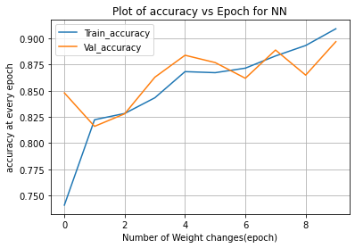

```python
# Training and Validation accuracy plotted against the number of the epochs for the model

from matplotlib import pyplot as plt
plt.plot(history_4.epoch,history_4.history['accuracy'], label = 'Train_accuracy')
plt.plot(history_4.epoch,history_4.history['val_accuracy'], label = 'Val_accuracy')
plt.grid()
plt.ylabel('accuracy at every epoch')
plt.xlabel('Number of Weight changes(epoch)')
plt.title('Plot of accuracy vs Epoch for NN')
plt.legend()
```

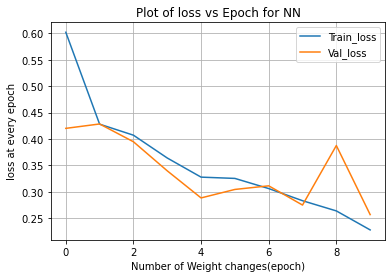

```python
# Training and Validation loss plotted against the number of the epochs for the model

from matplotlib import pyplot as plt
plt.plot(history_4.epoch,history_4.history['loss'], label = 'Train_loss')
plt.plot(history_4.epoch,history_4.history['val_loss'], label = 'Val_loss')
plt.grid()
plt.ylabel('loss at every epoch')
plt.xlabel('Number of Weight changes(epoch)')
plt.title('Plot of loss vs Epoch for NN')
plt.legend()
```

### From the graphs of accuracy and loss for Training vs Validation, it is evident that overfitting is no longer happening now as the curves are very close to each other with slight deviation around the 8th epoch. But the overall performance has been good. But it is computationally very expensive to build deeper CNN and takes a lot more time to get trained with each epoch taking almost double the previous time needed. These deeper networks can help in building more generalized models but a cost of high computation needed.

### Model 5

### The Change made to the network here is supplying an input image of reduced resolution to see how it effects the model

### The resolution/shape of the input image is reduced to half from the original input provided.

### Also, there are 2 more layers of higher filters later on added in the network. Now we have 2 filters of 128 and 256 filters each instead of only 1 for each filter number.

### Final Dense Feed Forward Neural Network has 1 extra layer of 512 neurons.

```python
model_5 = Sequential()
model_5.add(Conv2D(32, (3, 3), input_shape=(128,128,3)))
model_5.add(Activation('relu'))
model_5.add(MaxPooling2D(pool_size=(2, 2)))
model_5.add(Dropout(0.3))

model_5.add(Conv2D(64, (3, 3)))
model_5.add(Activation('relu'))
model_5.add(MaxPooling2D(pool_size=(2, 2)))
model_5.add(Dropout(0.3))

model_5.add(Conv2D(128, (3, 3)))
model_5.add(Conv2D(128, (3, 3)))
model_5.add(Activation('relu'))
model_5.add(Activation('relu'))
model_5.add(MaxPooling2D(pool_size=(2, 2)))
model_5.add(Dropout(0.3))

model_5.add(Conv2D(256, (3, 3)))
model_5.add(Conv2D(256, (3, 3)))
model_5.add(Activation('relu'))
model_5.add(Activation('relu'))
model_5.add(MaxPooling2D(pool_size=(2, 2)))
model_5.add(Dropout(0.5))

model_5.add(Flatten())
model_5.add(Dense(512))
model_5.add(Activation('relu'))
model_5.add(Dense(512))
model_5.add(Activation('relu'))
model_5.add(Dense(1))
model_5.add(Activation('sigmoid'))
```

```python
model_5.summary()
```

```
Model: "sequential_3"
_________________________________________________________________
Layer (type)                 Output Shape              Param #
=================================================================
conv2d_12 (Conv2D)           (None, 126, 126, 32)      896
_________________________________________________________________
activation_19 (Activation)   (None, 126, 126, 32)      0
_________________________________________________________________
max_pooling2d_10 (MaxPooling (None, 63, 63, 32)        0
_________________________________________________________________
dropout_10 (Dropout)         (None, 63, 63, 32)        0
_________________________________________________________________
conv2d_13 (Conv2D)           (None, 61, 61, 64)        18496
_________________________________________________________________
activation_20 (Activation)   (None, 61, 61, 64)        0
_________________________________________________________________
max_pooling2d_11 (MaxPooling (None, 30, 30, 64)        0
_________________________________________________________________
dropout_11 (Dropout)         (None, 30, 30, 64)        0
_________________________________________________________________
conv2d_14 (Conv2D)           (None, 28, 28, 128)       73856
_________________________________________________________________
conv2d_15 (Conv2D)           (None, 26, 26, 128)       147584
_________________________________________________________________
activation_21 (Activation)   (None, 26, 26, 128)       0
_________________________________________________________________
activation_22 (Activation)   (None, 26, 26, 128)       0
_________________________________________________________________
max_pooling2d_12 (MaxPooling (None, 13, 13, 128)       0
_________________________________________________________________
dropout_12 (Dropout)         (None, 13, 13, 128)       0
_________________________________________________________________
conv2d_16 (Conv2D)           (None, 11, 11, 256)       295168
_________________________________________________________________
conv2d_17 (Conv2D)           (None, 9, 9, 256)         590080
_________________________________________________________________
activation_23 (Activation)   (None, 9, 9, 256)         0
_________________________________________________________________
activation_24 (Activation)   (None, 9, 9, 256)         0
_________________________________________________________________
max_pooling2d_13 (MaxPooling (None, 4, 4, 256)         0
_________________________________________________________________
dropout_13 (Dropout)         (None, 4, 4, 256)         0
_________________________________________________________________
flatten_3 (Flatten)          (None, 4096)              0
_________________________________________________________________
dense_7 (Dense)              (None, 512)               2097664
_________________________________________________________________
activation_25 (Activation)   (None, 512)               0
_________________________________________________________________
dense_8 (Dense)              (None, 512)               262656
_________________________________________________________________
activation_26 (Activation)   (None, 512)               0
_________________________________________________________________
dense_9 (Dense)              (None, 1)                 513
_________________________________________________________________
activation_27 (Activation)   (None, 1)                 0
=================================================================
Total params: 3,486,913
Trainable params: 3,486,913
Non-trainable params: 0
_________________________________________________________________
```

### Number of weights in the model have to 3.4 million. We earlier had 14.7 million and 26 million weights. Now the model is very less complex in terms of number of weights to be updated as we have reduced the size of the input image along with increasing the depth of the CNN.

```python
# Defining the loss function for the image classification problem. As this is an binary image classification problem, using
# binary_crossentropy loss with Adam as the optimizer and metric as the accuracy.

model_5.compile(loss='binary_crossentropy',
              optimizer='adam',
              metrics=['accuracy'])
```

```python
# Fitting the model with input training images and validation images using images in the validation directory

history_5 = model_5.fit_generator(
        train1_generator,
        epochs=10,
        validation_data=validation1_generator,callbacks=[es])
```

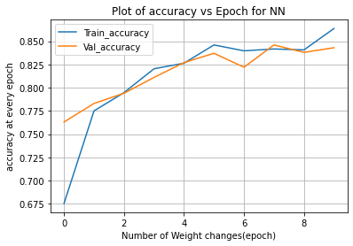

```python
# Training and Validation accuracy plotted against the number of the epochs for the model

from matplotlib import pyplot as plt
plt.plot(history_5.epoch,history_5.history['accuracy'], label = 'Train_accuracy')
plt.plot(history_5.epoch,history_5.history['val_accuracy'], label = 'Val_accuracy')
plt.grid()
plt.ylabel('accuracy at every epoch')
plt.xlabel('Number of Weight changes(epoch)')
plt.title('Plot of accuracy vs Epoch for NN')
plt.legend()
```

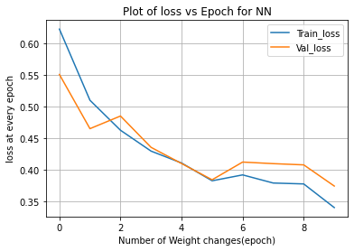

```python
# Training and Validation loss plotted against the number of the epochs for the model

from matplotlib import pyplot as plt
plt.plot(history_5.epoch,history_5.history['loss'], label = 'Train_loss')
plt.plot(history_5.epoch,history_5.history['val_loss'], label = 'Val_loss')
plt.grid()
plt.ylabel('loss at every epoch')
plt.xlabel('Number of Weight changes(epoch)')
plt.title('Plot of loss vs Epoch for NN')
plt.legend()
```

### From the graphs of accuracy and loss for the training vs Validation, it can be seen that the model is behaving almost the same for both training and validation images. The graphs indicate that at the very start the validation accuracy tends to be slightly higher than train but gradually the model fits better causing it reverse. But the overfitting of the model is eliminated and this model is by far the more generalized model out of the 5 models built. There is no problem of underfitting or overfitting and the 2 curves are very close to each other with the complexity of the network reduced by atleast 4 times if not by 9 times even though the image reolsution was reduced by half. The accuracy compared to other models has reduced but the model is more robust, less complex and time consuming and no overfitting or underfitting happening.

### Model 6

### Adding 1 more layer of Convolution with 64 filters and changing the dropout to increase gradually from 0.3 at the 1st Convolution layer, 0.4 for the next 2 layers and finally 0.5 for the final convoltional layer

### 3 layers for 256 filters Convolution layer instead of 2 causing the number of layers to go to 8 for the convolution and 2 dense layers before the final output

### Increasing the dropout gradually in the later layers and also more layers in the layer part of the network has any effect on the models is what I want to know by using this configuration

```python
model_6 = Sequential()
model_6.add(Conv2D(32, (3, 3), input_shape=(128,128,3)))
model_6.add(Activation('relu'))
model_6.add(MaxPooling2D(pool_size=(2, 2)))
model_6.add(Dropout(0.3))

model_6.add(Conv2D(64, (3, 3)))
model_6.add(Conv2D(64, (3, 3)))
model_6.add(Activation('relu'))
model_6.add(Activation('relu'))
model_6.add(MaxPooling2D(pool_size=(2, 2)))
model_6.add(Dropout(0.4))

model_6.add(Conv2D(128, (3, 3)))
model_6.add(Conv2D(128, (3, 3)))
model_6.add(Activation('relu'))
model_6.add(Activation('relu'))
model_6.add(MaxPooling2D(pool_size=(2, 2)))
model_6.add(Dropout(0.4))

model_6.add(Conv2D(256, (3, 3)))
model_6.add(Conv2D(256, (3, 3)))
model_6.add(Conv2D(256, (3, 3)))
model_6.add(Activation('relu'))
model_6.add(Activation('relu'))
model_6.add(Activation('relu'))
model_6.add(MaxPooling2D(pool_size=(2, 2)))
model_6.add(Dropout(0.5))

model_6.add(Flatten())
model_6.add(Dense(512))
model_6.add(Activation('relu'))
model_6.add(Dense(512))
model_6.add(Activation('relu'))
model_6.add(Dense(1))
model_6.add(Activation('sigmoid'))
```

```python
model_6.summary()
```

```
Model: "sequential_4"
_________________________________________________________________
Layer (type)                 Output Shape              Param #
=================================================================
conv2d_18 (Conv2D)           (None, 126, 126, 32)      896
_________________________________________________________________
activation_28 (Activation)   (None, 126, 126, 32)      0
_________________________________________________________________
max_pooling2d_14 (MaxPooling (None, 63, 63, 32)        0
_________________________________________________________________
dropout_14 (Dropout)         (None, 63, 63, 32)        0
_________________________________________________________________
conv2d_19 (Conv2D)           (None, 61, 61, 64)        18496
_________________________________________________________________
conv2d_20 (Conv2D)           (None, 59, 59, 64)        36928
_________________________________________________________________
activation_29 (Activation)   (None, 59, 59, 64)        0
_________________________________________________________________
activation_30 (Activation)   (None, 59, 59, 64)        0
_________________________________________________________________
max_pooling2d_15 (MaxPooling (None, 29, 29, 64)        0
_________________________________________________________________
dropout_15 (Dropout)         (None, 29, 29, 64)        0
_________________________________________________________________
conv2d_21 (Conv2D)           (None, 27, 27, 128)       73856
_________________________________________________________________
conv2d_22 (Conv2D)           (None, 25, 25, 128)       147584
_________________________________________________________________
activation_31 (Activation)   (None, 25, 25, 128)       0
_________________________________________________________________
activation_32 (Activation)   (None, 25, 25, 128)       0
_________________________________________________________________
max_pooling2d_16 (MaxPooling (None, 12, 12, 128)       0
_________________________________________________________________
dropout_16 (Dropout)         (None, 12, 12, 128)       0
_________________________________________________________________
conv2d_23 (Conv2D)           (None, 10, 10, 256)       295168
_________________________________________________________________
conv2d_24 (Conv2D)           (None, 8, 8, 256)         590080
_________________________________________________________________
```

[output cut: 15 more lines]

```
_________________________________________________________________
activation_36 (Activation)   (None, 512)               0
_________________________________________________________________
dense_11 (Dense)             (None, 512)               262656
_________________________________________________________________
activation_37 (Activation)   (None, 512)               0
_________________________________________________________________
dense_12 (Dense)             (None, 1)                 513
_________________________________________________________________
activation_38 (Activation)   (None, 1)                 0
=================================================================
Total params: 3,196,417
Trainable params: 3,196,417
Non-trainable params: 0
_________________________________________________________________
```

```python
# Defining the loss function for the image classification problem. As this is an binary image classification problem, using
# binary_crossentropy loss with Adam as the optimizer and metric as the accuracy.

model_6.compile(loss='binary_crossentropy',
              optimizer='adam',
              metrics=['accuracy'])
```

```python
# Fitting the model with input training images and validation images using images in the validation directory

history_6 = model_6.fit_generator(
        train1_generator,
        epochs=20,
        validation_data=validation1_generator,callbacks=[es])
```

```
Epoch 00004: early stopping
```

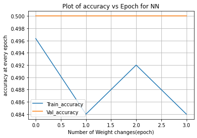

```python
# Training and Validation accuracy plotted against the number of the epochs for the model

from matplotlib import pyplot as plt
plt.plot(history_6.epoch,history_6.history['accuracy'], label = 'Train_accuracy')
plt.plot(history_6.epoch,history_6.history['val_accuracy'], label = 'Val_accuracy')
plt.grid()
plt.ylabel('accuracy at every epoch')
plt.xlabel('Number of Weight changes(epoch)')
plt.title('Plot of accuracy vs Epoch for NN')
plt.legend()
```

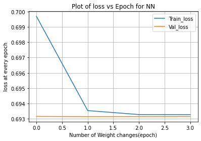

```python
# Training and Validation loss plotted against the number of the epochs for the model

from matplotlib import pyplot as plt
plt.plot(history_6.epoch,history_6.history['loss'], label = 'Train_loss')
plt.plot(history_6.epoch,history_6.history['val_loss'], label = 'Val_loss')
plt.grid()
plt.ylabel('loss at every epoch')
plt.xlabel('Number of Weight changes(epoch)')
plt.title('Plot of loss vs Epoch for NN')
plt.legend()
```

### The graph for accuracy and loss shows that the validation accuracy remains the same throughout at 0.5 with training accuracy changing slightly. Also, the loss is constant for validation set whereas for the train data it is dropping like a elbow curve. The performance is very poor for this model.

### Model 7

```python
model_7 = Sequential()
model_7.add(Conv2D(32, (3, 3), input_shape=(170,170,3)))
model_7.add(Activation('relu'))
model_7.add(MaxPooling2D(pool_size=(2, 2)))
model_7.add(Dropout(0.3))

model_7.add(Conv2D(64, (3, 3)))
model_7.add(Activation('relu'))
model_7.add(MaxPooling2D(pool_size=(2, 2)))
model_7.add(Dropout(0.4))

model_7.add(Conv2D(128, (3, 3)))
model_7.add(Conv2D(128, (3, 3)))
model_7.add(Activation('relu'))
model_7.add(Activation('relu'))
model_7.add(MaxPooling2D(pool_size=(2, 2)))
model_7.add(Dropout(0.4))

model_7.add(Conv2D(256, (3, 3)))
model_7.add(Conv2D(256, (3, 3)))
model_7.add(Conv2D(256, (3, 3)))
model_7.add(Activation('relu'))
model_7.add(Activation('relu'))
model_7.add(Activation('relu'))
model_7.add(MaxPooling2D(pool_size=(2, 2)))
model_7.add(Dropout(0.5))

model_7.add(Flatten())
model_7.add(Dense(512))
model_7.add(Activation('relu'))
model_7.add(Dense(512))
model_7.add(Activation('relu'))
model_7.add(Dense(1))
model_7.add(Activation('sigmoid'))
```

```python
model_7.summary()
```

```
Model: "sequential_5"
_________________________________________________________________
Layer (type)                 Output Shape              Param #
=================================================================
conv2d_26 (Conv2D)           (None, 168, 168, 32)      896
_________________________________________________________________
activation_39 (Activation)   (None, 168, 168, 32)      0
_________________________________________________________________
max_pooling2d_18 (MaxPooling (None, 84, 84, 32)        0
_________________________________________________________________
dropout_18 (Dropout)         (None, 84, 84, 32)        0
_________________________________________________________________
conv2d_27 (Conv2D)           (None, 82, 82, 64)        18496
_________________________________________________________________
activation_40 (Activation)   (None, 82, 82, 64)        0
_________________________________________________________________
max_pooling2d_19 (MaxPooling (None, 41, 41, 64)        0
_________________________________________________________________
dropout_19 (Dropout)         (None, 41, 41, 64)        0
_________________________________________________________________
conv2d_28 (Conv2D)           (None, 39, 39, 128)       73856
_________________________________________________________________
conv2d_29 (Conv2D)           (None, 37, 37, 128)       147584
_________________________________________________________________
activation_41 (Activation)   (None, 37, 37, 128)       0
_________________________________________________________________
activation_42 (Activation)   (None, 37, 37, 128)       0
_________________________________________________________________
max_pooling2d_20 (MaxPooling (None, 18, 18, 128)       0
_________________________________________________________________
dropout_20 (Dropout)         (None, 18, 18, 128)       0
_________________________________________________________________
conv2d_30 (Conv2D)           (None, 16, 16, 256)       295168
_________________________________________________________________
conv2d_31 (Conv2D)           (None, 14, 14, 256)       590080
_________________________________________________________________
conv2d_32 (Conv2D)           (None, 12, 12, 256)       590080
_________________________________________________________________
activation_43 (Activation)   (None, 12, 12, 256)       0
_________________________________________________________________
```

[output cut: 11 more lines]

```
_________________________________________________________________
activation_46 (Activation)   (None, 512)               0
_________________________________________________________________
dense_14 (Dense)             (None, 512)               262656
_________________________________________________________________
activation_47 (Activation)   (None, 512)               0
_________________________________________________________________
dense_15 (Dense)             (None, 1)                 513
_________________________________________________________________
activation_48 (Activation)   (None, 1)                 0
=================================================================
Total params: 6,698,433
Trainable params: 6,698,433
Non-trainable params: 0
_________________________________________________________________
```

### Number of weights have doubled to 6.6 from 3.4 million by increasing the size of the input image and creating a complex network

```python
# Defining the loss function for the image classification problem. As this is an binary image classification problem, using
# binary_crossentropy loss with Adam as the optimizer and metric as the accuracy.

model_7.compile(loss='binary_crossentropy',
              optimizer='adam',
              metrics=['accuracy'])
```

```python
# Fitting the model with input training images and validation images using images in the validation directory

history_7 = model_7.fit_generator(
        train2_generator,
        epochs=20,
        validation_data=validation2_generator,callbacks=[es])
```

```
Epoch 00004: early stopping
```

### The training process is stopped after 4th epoch due to the fact that the performance is the same even when we increase the resolution of the image to somewhat higher value.

### Model 8

### Now changing the Kernel Size for Convolution from 3*3 to 5*5 is being explored to see if having bigger window size creates a better model or not.

### 6 convolution layers are created with input image size 128*128 and the dropout of 0.3 is kept for the initial layers whereas for the final layers it is increased to 0.5 not increasing gradually from 0.3 to 0.4 and from 0.4 to 0.5.

```python
model_8 = Sequential()
model_8.add(Conv2D(32, (5, 5), input_shape=(128,128,3)))
model_8.add(Activation('relu'))
model_8.add(MaxPooling2D(pool_size=(2, 2)))
model_8.add(Dropout(0.3))

model_8.add(Conv2D(64, (5, 5)))
model_8.add(Activation('relu'))
model_8.add(MaxPooling2D(pool_size=(2, 2)))
model_8.add(Dropout(0.3))

model_8.add(Conv2D(128, (5, 5)))
model_8.add(Conv2D(128, (5, 5)))
model_8.add(Activation('relu'))
model_8.add(Activation('relu'))
model_8.add(MaxPooling2D(pool_size=(2, 2)))
model_8.add(Dropout(0.3))

model_8.add(Conv2D(256, (5, 5)))
model_8.add(Conv2D(256, (5, 5)))
model_8.add(Activation('relu'))
model_8.add(Activation('relu'))
model_8.add(MaxPooling2D(pool_size=(2, 2)))
model_8.add(Dropout(0.5))

model_8.add(Flatten())
model_8.add(Dense(512))
model_8.add(Activation('relu'))
model_8.add(Dense(512))
model_8.add(Activation('relu'))
model_8.add(Dense(1))
model_8.add(Activation('sigmoid'))
```

```python
model_8.summary()
```

```
Model: "sequential_6"
_________________________________________________________________
Layer (type)                 Output Shape              Param #
=================================================================
conv2d_33 (Conv2D)           (None, 124, 124, 32)      2432
_________________________________________________________________
activation_49 (Activation)   (None, 124, 124, 32)      0
_________________________________________________________________
max_pooling2d_22 (MaxPooling (None, 62, 62, 32)        0
_________________________________________________________________
dropout_22 (Dropout)         (None, 62, 62, 32)        0
_________________________________________________________________
conv2d_34 (Conv2D)           (None, 58, 58, 64)        51264
_________________________________________________________________
activation_50 (Activation)   (None, 58, 58, 64)        0
_________________________________________________________________
max_pooling2d_23 (MaxPooling (None, 29, 29, 64)        0
_________________________________________________________________
dropout_23 (Dropout)         (None, 29, 29, 64)        0
_________________________________________________________________
conv2d_35 (Conv2D)           (None, 25, 25, 128)       204928
_________________________________________________________________
conv2d_36 (Conv2D)           (None, 21, 21, 128)       409728
_________________________________________________________________
activation_51 (Activation)   (None, 21, 21, 128)       0
_________________________________________________________________
activation_52 (Activation)   (None, 21, 21, 128)       0
_________________________________________________________________
max_pooling2d_24 (MaxPooling (None, 10, 10, 128)       0
_________________________________________________________________
dropout_24 (Dropout)         (None, 10, 10, 128)       0
_________________________________________________________________
conv2d_37 (Conv2D)           (None, 6, 6, 256)         819456
_________________________________________________________________
conv2d_38 (Conv2D)           (None, 2, 2, 256)         1638656
_________________________________________________________________
activation_53 (Activation)   (None, 2, 2, 256)         0
_________________________________________________________________
activation_54 (Activation)   (None, 2, 2, 256)         0
_________________________________________________________________
max_pooling2d_25 (MaxPooling (None, 1, 1, 256)         0
_________________________________________________________________
dropout_25 (Dropout)         (None, 1, 1, 256)         0
_________________________________________________________________
flatten_6 (Flatten)          (None, 256)               0
_________________________________________________________________
dense_16 (Dense)             (None, 512)               131584
_________________________________________________________________
activation_55 (Activation)   (None, 512)               0
_________________________________________________________________
dense_17 (Dense)             (None, 512)               262656
_________________________________________________________________
activation_56 (Activation)   (None, 512)               0
_________________________________________________________________
dense_18 (Dense)             (None, 1)                 513
_________________________________________________________________
activation_57 (Activation)   (None, 1)                 0
=================================================================
Total params: 3,521,217
Trainable params: 3,521,217
Non-trainable params: 0
_________________________________________________________________
```

### Number of weights have increased to 3.5 million from 3.4 million as we have increased the kernel size. There is only a small change in the complexity of the network.

```python
# Defining the loss function for the image classification problem. As this is an binary image classification problem, using
# binary_crossentropy loss with Adam as the optimizer and metric as the accuracy.

model_8.compile(loss='binary_crossentropy',
              optimizer='adam',
              metrics=['accuracy'])
```

```python
# Fitting the model with input training images and validation images using images in the validation directory

history_8 = model_8.fit_generator(
        train1_generator,
        epochs=20,
        validation_data=validation1_generator,callbacks=[es])
```

```
Epoch 00016: early stopping
```

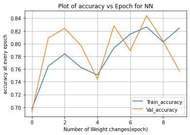

```python
# Training and Validation accuracy plotted against the number of the epochs for the model

from matplotlib import pyplot as plt
plt.plot(history_8.epoch[0:10],history_8.history['accuracy'][0:10], label = 'Train_accuracy')
plt.plot(history_8.epoch[0:10],history_8.history['val_accuracy'][0:10], label = 'Val_accuracy')
plt.grid()
plt.ylabel('accuracy at every epoch')
plt.xlabel('Number of Weight changes(epoch)')
plt.title('Plot of accuracy vs Epoch for NN')
plt.legend()
```

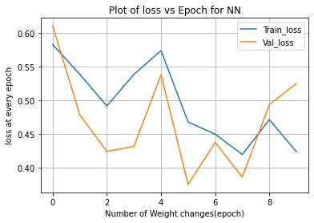

```python
# Training and Validation loss plotted against the number of the epochs for the model

from matplotlib import pyplot as plt
plt.plot(history_8.epoch[0:10],history_8.history['loss'][0:10], label = 'Train_loss')
plt.plot(history_8.epoch[0:10],history_8.history['val_loss'][0:10], label = 'Val_loss')
plt.grid()
plt.ylabel('loss at every epoch')
plt.xlabel('Number of Weight changes(epoch)')
plt.title('Plot of loss vs Epoch for NN')
plt.legend()
```

### This underfitting would be caused by using dropout as for the training we have less number of nodes due to the dropout causing the model to not fit properly whereas for the validation data we are using all the nodes without dropping them out making the model to perform better on validation image data as there are more points available.

### Model 9

### Now removing the dropout after each convolution layer and only using the dropout once with 0.3 at the end after 2 dense layers to see its effect

### It might be becuase of the dropout the model was underfitting earlier

```python
model_9 = Sequential()
model_9.add(Conv2D(32, (5, 5), input_shape=(128,128,3)))
model_9.add(Activation('relu'))
model_9.add(MaxPooling2D(pool_size=(2, 2)))

model_9.add(Conv2D(64, (5, 5)))
model_9.add(Activation('relu'))
model_9.add(MaxPooling2D(pool_size=(2, 2)))

model_9.add(Conv2D(128, (5, 5)))
model_9.add(Conv2D(128, (5, 5)))
model_9.add(Activation('relu'))
model_9.add(Activation('relu'))
model_9.add(MaxPooling2D(pool_size=(2, 2)))

model_9.add(Conv2D(256, (5, 5)))
model_9.add(Conv2D(256, (5, 5)))
model_9.add(Activation('relu'))
model_9.add(Activation('relu'))
model_9.add(MaxPooling2D(pool_size=(2, 2)))

model_9.add(Flatten())
model_9.add(Dense(512))
model_9.add(Activation('relu'))
model_9.add(Dense(512))
model_9.add(Activation('relu'))
model_9.add(Dropout(0.3))
model_9.add(Dense(1))
model_9.add(Activation('sigmoid'))
```

```python
model_9.summary()
```

```
Model: "sequential_7"
_________________________________________________________________
Layer (type)                 Output Shape              Param #
=================================================================
conv2d_39 (Conv2D)           (None, 124, 124, 32)      2432
_________________________________________________________________
activation_58 (Activation)   (None, 124, 124, 32)      0
_________________________________________________________________
max_pooling2d_26 (MaxPooling (None, 62, 62, 32)        0
_________________________________________________________________
conv2d_40 (Conv2D)           (None, 58, 58, 64)        51264
_________________________________________________________________
activation_59 (Activation)   (None, 58, 58, 64)        0
_________________________________________________________________
max_pooling2d_27 (MaxPooling (None, 29, 29, 64)        0
_________________________________________________________________
conv2d_41 (Conv2D)           (None, 25, 25, 128)       204928
_________________________________________________________________
conv2d_42 (Conv2D)           (None, 21, 21, 128)       409728
_________________________________________________________________
activation_60 (Activation)   (None, 21, 21, 128)       0
_________________________________________________________________
activation_61 (Activation)   (None, 21, 21, 128)       0
_________________________________________________________________
max_pooling2d_28 (MaxPooling (None, 10, 10, 128)       0
_________________________________________________________________
conv2d_43 (Conv2D)           (None, 6, 6, 256)         819456
_________________________________________________________________
conv2d_44 (Conv2D)           (None, 2, 2, 256)         1638656
_________________________________________________________________
activation_62 (Activation)   (None, 2, 2, 256)         0
_________________________________________________________________
activation_63 (Activation)   (None, 2, 2, 256)         0
_________________________________________________________________
max_pooling2d_29 (MaxPooling (None, 1, 1, 256)         0
_________________________________________________________________
flatten_7 (Flatten)          (None, 256)               0
_________________________________________________________________
dense_19 (Dense)             (None, 512)               131584
_________________________________________________________________
activation_64 (Activation)   (None, 512)               0
_________________________________________________________________
dense_20 (Dense)             (None, 512)               262656
_________________________________________________________________
activation_65 (Activation)   (None, 512)               0
_________________________________________________________________
dropout_26 (Dropout)         (None, 512)               0
_________________________________________________________________
dense_21 (Dense)             (None, 1)                 513
_________________________________________________________________
activation_66 (Activation)   (None, 1)                 0
=================================================================
Total params: 3,521,217
Trainable params: 3,521,217
Non-trainable params: 0
_________________________________________________________________
```

```python
# Defining the loss function for the image classification problem. As this is an binary image classification problem, using
# binary_crossentropy loss with Adam as the optimizer and metric as the accuracy.

model_9.compile(loss='binary_crossentropy',
              optimizer='adam',
              metrics=['accuracy'])
```

```python
# Fitting the model with input training images and validation images using images in the validation directory

history_9 = model_9.fit_generator(
        train1_generator,
        epochs=10,
        validation_data=validation1_generator,callbacks=[es])
```

```
Epoch 00008: early stopping
```

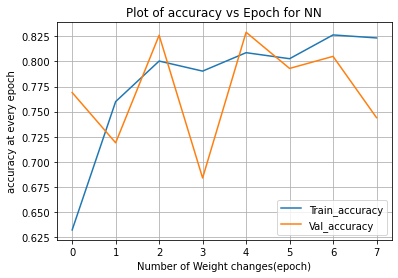

```python
# Training and Validation accuracy plotted against the number of the epochs for the model

from matplotlib import pyplot as plt
plt.plot(history_9.epoch,history_9.history['accuracy'], label = 'Train_accuracy')
plt.plot(history_9.epoch,history_9.history['val_accuracy'], label = 'Val_accuracy')
plt.grid()
plt.ylabel('accuracy at every epoch')
plt.xlabel('Number of Weight changes(epoch)')
plt.title('Plot of accuracy vs Epoch for NN')
plt.legend()
```

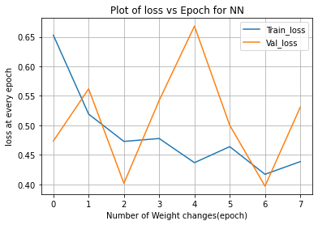

```python
# Training and Validation loss plotted against the number of the epochs for the model

from matplotlib import pyplot as plt
plt.plot(history_9.epoch,history_9.history['loss'], label = 'Train_loss')
plt.plot(history_9.epoch,history_9.history['val_loss'], label = 'Val_loss')
plt.grid()
plt.ylabel('loss at every epoch')
plt.xlabel('Number of Weight changes(epoch)')
plt.title('Plot of loss vs Epoch for NN')
plt.legend()
```

### Now dropping the nodes randomly only once at the final stage has reduced the underfitting as seen from the graphs above of the train vs validation accuracy and loss. There is underfitting but the magnitude is reduced and it is not happening throughout the time.

# Plotting the Accuracy and Loss for Validation Image Data for different models built

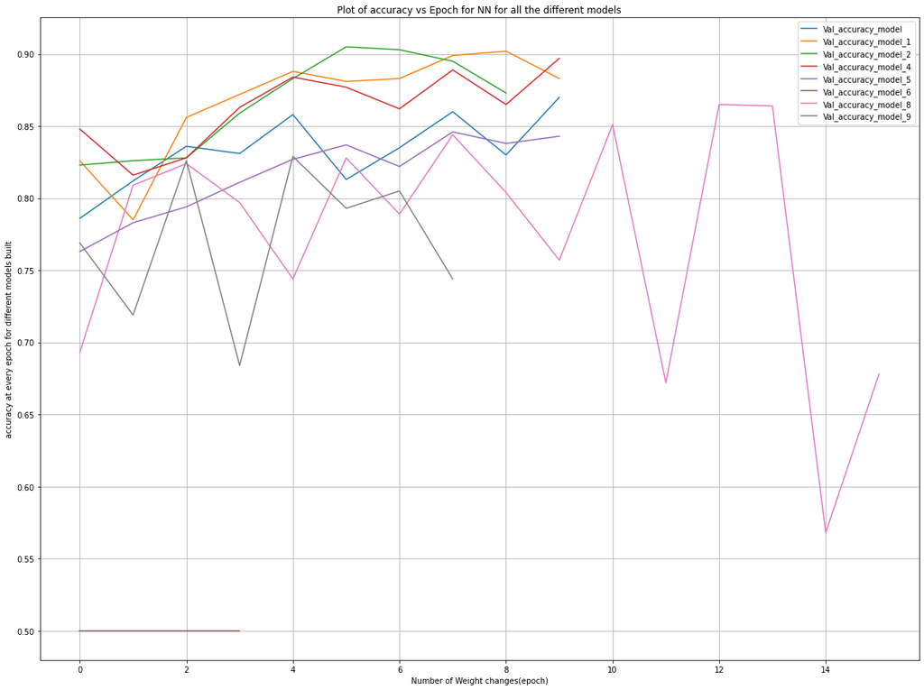

```python
from matplotlib import pyplot as plt
plt.figure(figsize=(20,15))
plt.plot(history.epoch,history.history['val_accuracy'], label = 'Val_accuracy_model')
plt.plot(history_1.epoch,history_1.history['val_accuracy'], label = 'Val_accuracy_model_1')
plt.plot(history_2.epoch,history_2.history['val_accuracy'], label = 'Val_accuracy_model_2')
plt.plot(history_4.epoch,history_4.history['val_accuracy'], label = 'Val_accuracy_model_4')
plt.plot(history_5.epoch,history_5.history['val_accuracy'], label = 'Val_accuracy_model_5')
plt.plot(history_6.epoch,history_6.history['val_accuracy'], label = 'Val_accuracy_model_6')
plt.plot(history_8.epoch,history_8.history['val_accuracy'], label = 'Val_accuracy_model_8')
plt.plot(history_9.epoch,history_9.history['val_accuracy'], label = 'Val_accuracy_model_9')
plt.grid()
plt.ylabel('accuracy at every epoch for different models built')
plt.xlabel('Number of Weight changes(epoch)')
plt.title('Plot of accuracy vs Epoch for NN for all the different models')
plt.legend()
```

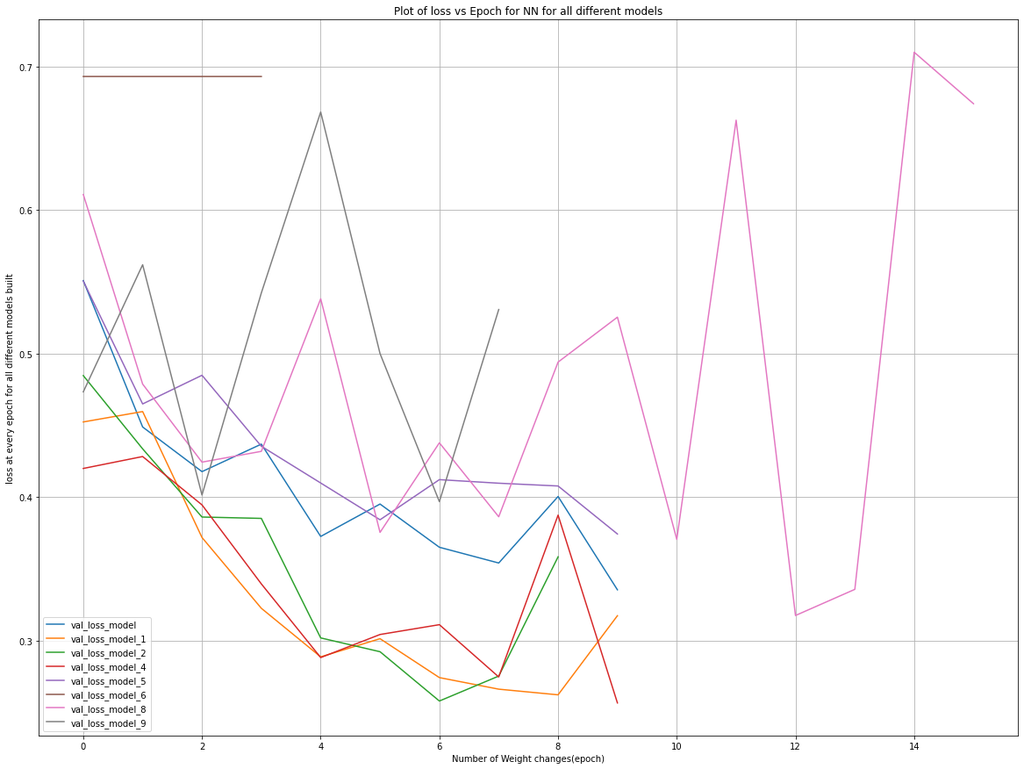

```python
from matplotlib import pyplot as plt
plt.figure(figsize=(20,15))
plt.plot(history.epoch,history.history['val_loss'], label = 'val_loss_model')
plt.plot(history_1.epoch,history_1.history['val_loss'], label = 'val_loss_model_1')
plt.plot(history_2.epoch,history_2.history['val_loss'], label = 'val_loss_model_2')
plt.plot(history_4.epoch,history_4.history['val_loss'], label = 'val_loss_model_4')
plt.plot(history_5.epoch,history_5.history['val_loss'], label = 'val_loss_model_5')
plt.plot(history_6.epoch,history_6.history['val_loss'], label = 'val_loss_model_6')
plt.plot(history_8.epoch,history_8.history['val_loss'], label = 'val_loss_model_8')
plt.plot(history_9.epoch,history_9.history['val_loss'], label = 'val_loss_model_9')
plt.grid()
plt.ylabel('loss at every epoch for all different models built')
plt.xlabel('Number of Weight changes(epoch)')
plt.title('Plot of loss vs Epoch for NN for all different models')
plt.legend()
```

# Conclusion

### Underfitting and overfitting can become problem in the CNN networks so it is good idea to use EarlyStopping in order to save the model overfittting, avoid from training for unnecessary time consuming computation.

### Hyper parameters such as Kernel size, number of filters, Pooling technique and size along with dropout play key role in building a robust network.